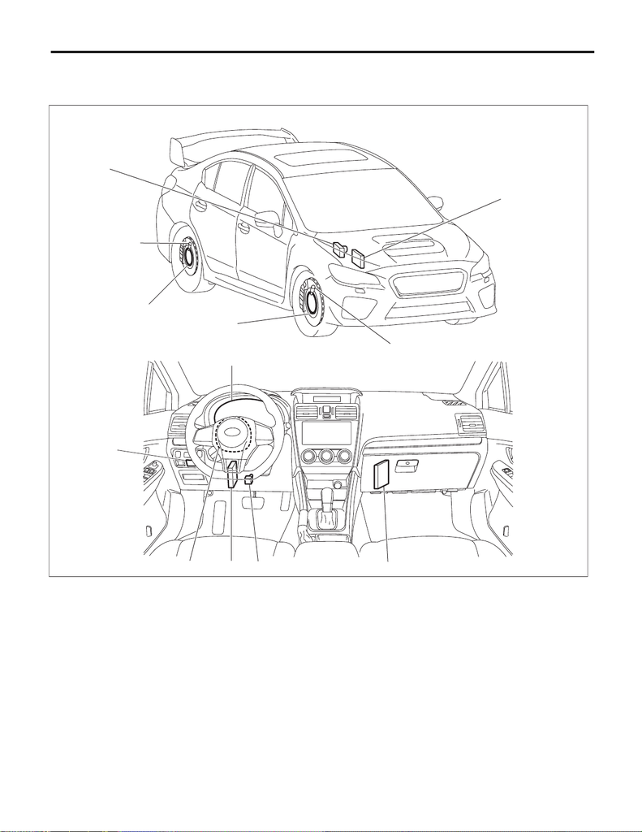

Electrical Component Location

VEHICLE DYNAMICS CONTROL (VDC) (DIAGNOSTICS)

4. Electrical Component Location

A: LOCATION

(1) VDC control module and hydraulic

control unit (VDCCM&H/U)

(6) VDC OFF indicator light (11) Magnetic encoder

(2) VDC OFF switch (7) Hill start assist warning light (12) ABS wheel speed sensor

(3) ABS warning light (8) VDC traction mode indicator light (13) Engine control module (ECM)

(except for STI)

(4) Brake warning light (EBD warning

light)

(9) Steering angle sensor (14) Engine control module (ECM) (STI

model)

(5) VDC warning light & VDC indica-

tor light

(10) Stop light and brake switch (15) Transmission control module

(TCM)

VDC01297

(1)

(13)

(12)

(11)

(2)

(9)

(11)

(12)

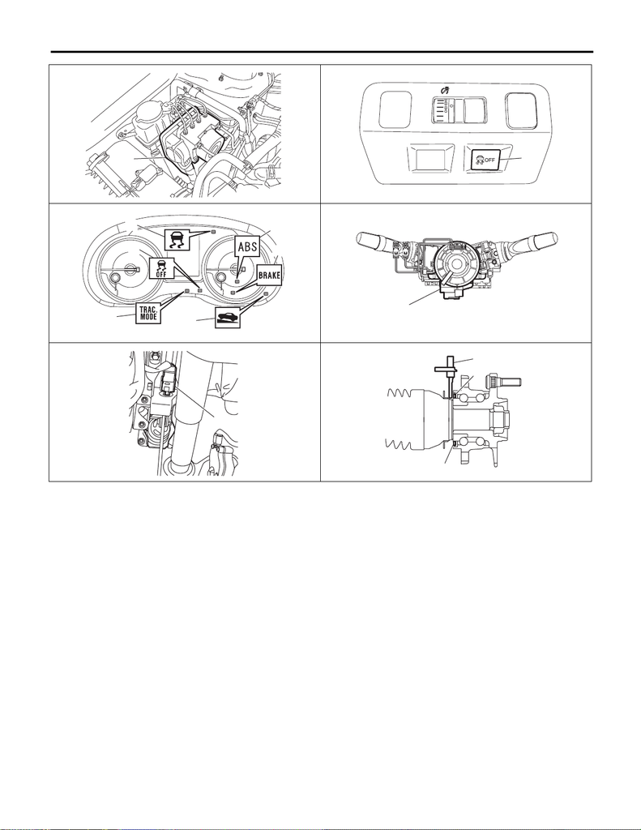

Electrical Component Location

VEHICLE DYNAMICS CONTROL (VDC) (DIAGNOSTICS)

VDC01270

(1)

(2)

VDC01275

VDC01298

(3)

(7)

(5)

(4)

(6)

(8)

(9)

VDC01301

VDC01302

(10)

VDC00741

(12)

(11)

(11)